# Musser-Grace-ADA-DATA-REANALYSIS-ASSIGNMENT

Grace Musser

4/2/2019

## Introduction

This paper uses novel endocast data, data from previously published phylogenetic analsyes, and ancestral state reconstruction to assess vision capacity in paleognathous birds and hypothesize their habitat types (eg open, forested). It is clear that the authors at least used the ape and phytools packages in R. They performed ANOVA tests, used PGLS (phylogenetic least squares regression), and tree visualization and ancestral state reconstruction to attain their results. The authors provided trees and measurements but did not provide R code.

```r
# First, I loaded in the following packages:
library(ctv)
library(phytools)
library(ape)
library(nlme)
library(geiger)
# Load in the trees, which are in Newick notation, into tree files which are
# class 'phylo'.
tree_2 <- read.tree("rspb20181540supp2.txt")
tree_3 <- read.tree("rspb20181540supp3.txt")
tree_4 <- read.tree("rspb20181540supp4.txt")
tree_5 <- read.tree("rspb20181540supp5.txt")
```

```r
# Here, the brain measurements are read in from a .csv file. There are
# header and row names.
brain_meas <- read.csv("TableS2.csv", header = TRUE, row.names = 1)
head(brain_meas)
```

```
##                           OLA    TBA OptR   OBL   CHL   OR Habitat
## Casuarius_casuarius      2.99  81.12 0.04 11.27 42.12 0.27      NA
## Dromaius_novaehollandiae 2.34  52.52 0.04  8.37 31.51 0.27      NA
## Aepyornis_maximus        1.42 119.38 0.01 11.74 44.40 0.26      NA
## Pachyornis_elephantopus  1.29  65.03 0.02  7.80 36.55 0.21      NA
## Struthio_camelus         2.58  77.09 0.03  6.88 39.10 0.18      NA
## Rhea_americana           2.08  45.06 0.05  7.37 33.40 0.22      NA
##                          Olfactory.Ratio
## Casuarius_casuarius            0.2675689
## Dromaius_novaehollandiae       0.2656300
## Aepyornis_maximus              0.2644144
## Pachyornis_elephantopus        0.2134063
## Struthio_camelus               0.1759591
## Rhea_americana                 0.2206587
```

```r
# The authors based stats and visualiztions on tree 4, so we will focus on
# reanalysis of this tree. First, we need to check that the names in the csv
# file and the names in the tree match. They did not at first, so names had
# to be deleted.
obj <- name.check(tree_4, brain_meas)  #check name matching across tree and table
obj
```

```
## $tree_not_data
## [1] "Apteryx_australis"
##
## $data_not_tree
## character(0)
```

```r
# We pruned names in the tree that did not match those in the dataframe.
pruned <- drop.tip(tree_4, obj$tree_not_data)  #prune tips that do not match data
pruned
```

```
##
## Phylogenetic tree with 98 tips and 97 internal nodes.
##
## Tip labels:
##  Pitta_brachyura, Hirundo_rustica, Cinclus_cinclus, Motacilla_madaraspatensis, Motacilla_flava, Amandava_amandava, ...
##
## Rooted; includes branch lengths.
```

```r
# When rechecking the names, we can see that they now match.
name.check(pruned, brain_meas)  #double check again that all names match across data and tree
```

```
## [1] "OK"
```

PGLS using ape:

First, simple model using Brownian motion:

```r
bm <- corBrownian(1, pruned)  #define covariance structure (Brownian motion)
bm
```

```
## Uninitialized correlation structure of class corBrownian
```

```r
modelo1 <- gls(OBL ~ CHL, data = brain_meas, correlation = bm)  #OBL=olfactory bulb length, CHL=cerebral hemisphere length
# olfactory bulb ratio=olfactory bulb length to cerebral hemisphere length
summary(modelo1)  #get the summary of the PGLS
```

```
## Generalized least squares fit by REML
##   Model: OBL ~ CHL
##   Data: brain_meas
##        AIC      BIC    logLik
##   288.1483 295.8414 -141.0742
##
## Correlation Structure: corBrownian
##  Formula: ~1
##  Parameter estimate(s):
## numeric(0)
##
## Coefficients:
##                 Value Std.Error  t-value p-value
## (Intercept) 1.6063872 0.8378216 1.917338  0.0582
## CHL         0.1366442 0.0181493 7.528883  0.0000
##
##  Correlation:
##     (Intr)
## CHL -0.511
##
## Standardized residuals:
##        Min         Q1        Med         Q3        Max
## -2.2090663 -0.8157879 -0.4960634  0.0697805  2.3278304
##
## Residual standard error: 1.746953
## Degrees of freedom: 98 total; 96 residual
```

Relaxed Brownian motion model (Lambda model of Pagel):

```r
modelo2 <- gls(OBL ~ CHL, data = brain_meas, correlation = corPagel(1, pruned))
summary(modelo2)  #this model is more complex and based on that of Pagel
```

```
## Generalized least squares fit by REML
##   Model: OBL ~ CHL
##   Data: brain_meas
##        AIC      BIC    logLik
##   284.6331 294.8905 -138.3166
##
## Correlation Structure: corPagel
##  Formula: ~1
##  Parameter estimate(s):
##    lambda
## 0.8438517
##
## Coefficients:
##                 Value Std.Error  t-value p-value
## (Intercept) 1.0347889 0.6611537 1.565126  0.1208
## CHL         0.1604125 0.0174133 9.212067  0.0000
##
##  Correlation:
##     (Intr)
## CHL -0.61
##
## Standardized residuals:
##        Min         Q1        Med         Q3        Max
## -2.8724155 -0.9103972 -0.5174974  0.1866771  2.6351388
##
## Residual standard error: 1.359662
## Degrees of freedom: 98 total; 96 residual
```

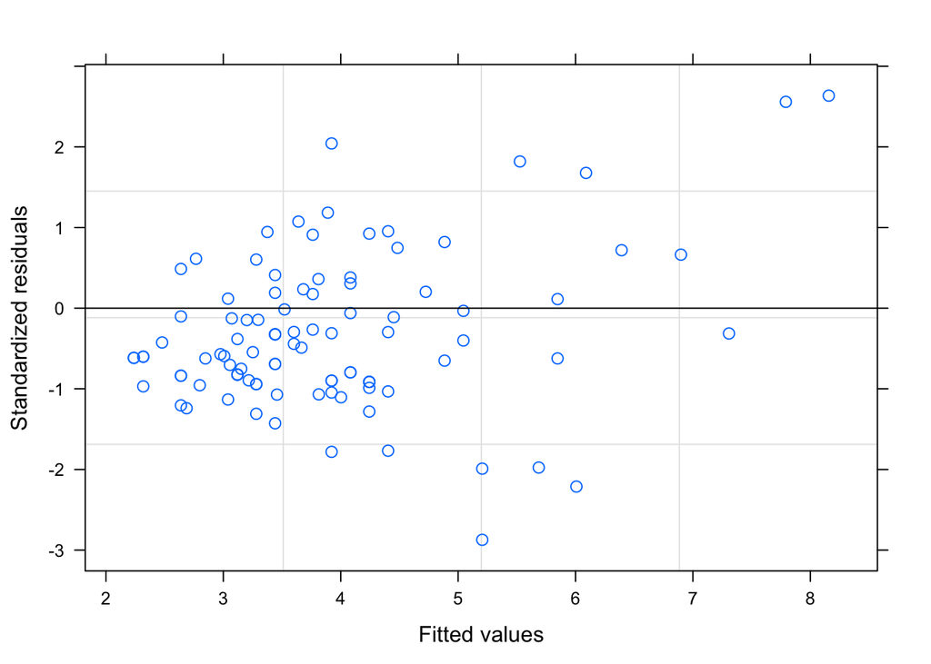

```r
plot(modelo2)  #plot the PGLS--additionaledits performed in photoshop by authors
```

Multiple regression PGLS:

```r
modelo3 <- gls(OBL ~ CHL + OR, data = brain_meas, correlation = corPagel(1,
    pruned))
summary(modelo3)  #this is a pagel model which takes olfactory ratio into account when comparing olfactory bulb length and cerebral hemisphere length
```

```
## Generalized least squares fit by REML
##   Model: OBL ~ CHL + OR
##   Data: brain_meas
##        AIC      BIC    logLik
##   118.1004 130.8698 -54.05019
##
## Correlation Structure: corPagel
##  Formula: ~1
##  Parameter estimate(s):
##   lambda
## 1.003453
##
## Coefficients:
##                 Value Std.Error   t-value p-value
## (Intercept) -3.380709 0.4059118 -8.328678       0
## CHL          0.189862 0.0078235 24.268082       0
## OR          18.473219 0.7634399 24.197345       0
##
##  Correlation:
##     (Intr) CHL
## CHL -0.563
## OR  -0.510  0.285
##
## Standardized residuals:
##         Min          Q1         Med          Q3         Max
## -1.85429510 -0.33084400 -0.19860524  0.02689449  2.58853016
##
## Residual standard error: 0.7292963
## Degrees of freedom: 98 total; 95 residual
```

```r
# One can use ace to find anova scores and CI of internal nodes in ape:
ace(brain_meas$Olfactory.Ratio, pruned, method = "GLS", corStruct = corBrownian(1,
    pruned), CI = TRUE)
```

```
##
##     Ancestral Character Estimation
##
## Call: ace(x = brain_meas$Olfactory.Ratio, phy = pruned, method = "GLS",
##     CI = TRUE, corStruct = corBrownian(1, pruned))
##
## $ace
##         99        100        101        102        103        104
## 0.24511837 0.22200609 0.17650597 0.17001879 0.16312645 0.15753446
##        105        106        107        108        109        110
## 0.16006968 0.21103096 0.21138903 0.22920544 0.22918575 0.21974625
##        111        112        113        114        115        116
## 0.19739607 0.19145087 0.19215397 0.19524629 0.18445568 0.16244820
##        117        118        119        120        121        122
## 0.15511202 0.15197717 0.13353328 0.12071055 0.10697183 0.09947741
```

[output cut: 126 more lines]

```r
anova(modelo2)  #perform an ANOVA on the second model
```

```
## Denom. DF: 96
##             numDF  F-value p-value
## (Intercept)     1 82.19802  <.0001
## CHL             1 84.86218  <.0001
```

# The authors did not provide their scorings for habitat type. If I were to perform an ANOVA taking habitat type into account, I would score each taxon as having a habitat type of forest dwelling (=1) or open (=0).

```r
anova(modelo3)  #perform an ANOVA on the third model
```

```
## Denom. DF: 95
##             numDF  F-value p-value
## (Intercept)     1 257.5338  <.0001
## CHL             1 328.1273  <.0001
## OR              1 585.5115  <.0001
```

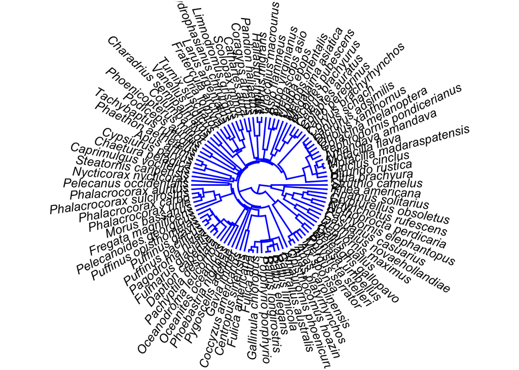

```r
# There are many ways to visualize trees using these packages. Here, we try
# the fan tree:
plotTree(pruned, type = "fan", color = "blue", ftype = "i")  #plot tree in fan style
```

```r
# before performing ancestral state reconstruction, we need to make syre
# that our data is vectorized
svl <- as.matrix(brain_meas$Olfactory.Ratio)[, 1]  #turn olfactory ratio column into matrix
fit <- fastAnc(pruned, svl, vars = TRUE, CI = TRUE)  #ancestral state reconstructions per node, confidence intervals
fit
```

```
## Ancestral character estimates using fastAnc:
##       99      100      101      102      103      104      105      106
## 0.245118 0.222006 0.176506 0.170019 0.163126 0.157534 0.160070 0.211031
##      107      108      109      110      111      112      113      114
## 0.211389 0.229205 0.229186 0.219746 0.197396 0.191451 0.192154 0.195246
##      115      116      117      118      119      120      121      122
## 0.184456 0.162448 0.155112 0.151977 0.133533 0.120711 0.106972 0.099477
##      123      124      125      126      127      128      129      130
## 0.098448 0.139491 0.121016 0.119128 0.153529 0.140142 0.134703 0.143223
##      131      132      133      134      135      136      137      138
## 0.152399 0.151222 0.147607 0.144399 0.150994 0.149529 0.149691 0.150568
##      139      140      141      142      143      144      145      146
## 0.168510 0.167727 0.167253 0.163539 0.155522 0.167672 0.166898 0.160398
##      147      148      149      150      151      152      153      154
## 0.158949 0.180457 0.183944 0.184205 0.184144 0.182654 0.180774 0.180665
```

[output cut: 140 more lines]

```r
# again, we vectorize data....
svl2 <- as.matrix(brain_meas)[, 8]
fit <- fastAnc(pruned, svl2, vars = TRUE, CI = TRUE)  #and perform ancestral state reconstruction
fit
```

```
## Ancestral character estimates using fastAnc:
##       99      100      101      102      103      104      105      106
## 0.201424 0.195149 0.193734 0.192714 0.185546 0.180131 0.178760 0.157692
##      107      108      109      110      111      112      113      114
## 0.140687 0.132588 0.131986 0.129898 0.149175 0.138123 0.136727 0.136144
##      115      116      117      118      119      120      121      122
## 0.134666 0.129746 0.178558 0.176307 0.166658 0.160665 0.140150 0.116820
##      123      124      125      126      127      128      129      130
## 0.115548 0.162094 0.173665 0.171467 0.177992 0.150554 0.139372 0.202699
##      131      132      133      134      135      136      137      138
## 0.170077 0.166904 0.171979 0.164062 0.163627 0.153782 0.150566 0.181411
##      139      140      141      142      143      144      145      146
## 0.196354 0.197609 0.198343 0.206580 0.237897 0.201835 0.203966 0.189408
##      147      148      149      150      151      152      153      154
## 0.187822 0.194955 0.194633 0.193857 0.192809 0.185448 0.181202 0.149185
```

[output cut: 140 more lines]

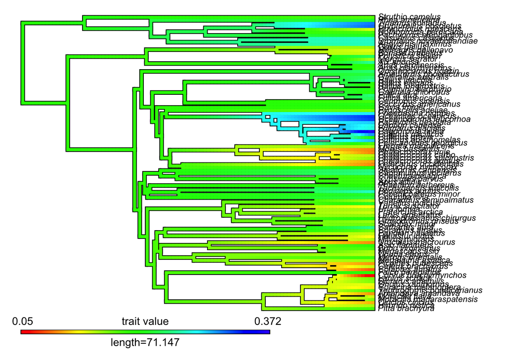

```r
# the contMap function allows us to visualize the tree with ancestral state
# reconstructions mapped using colors
obj <- contMap(pruned, svl2, legend = 0.7 * max(nodeHeights(pruned)), fsize = c(0.7,
    0.9))
```

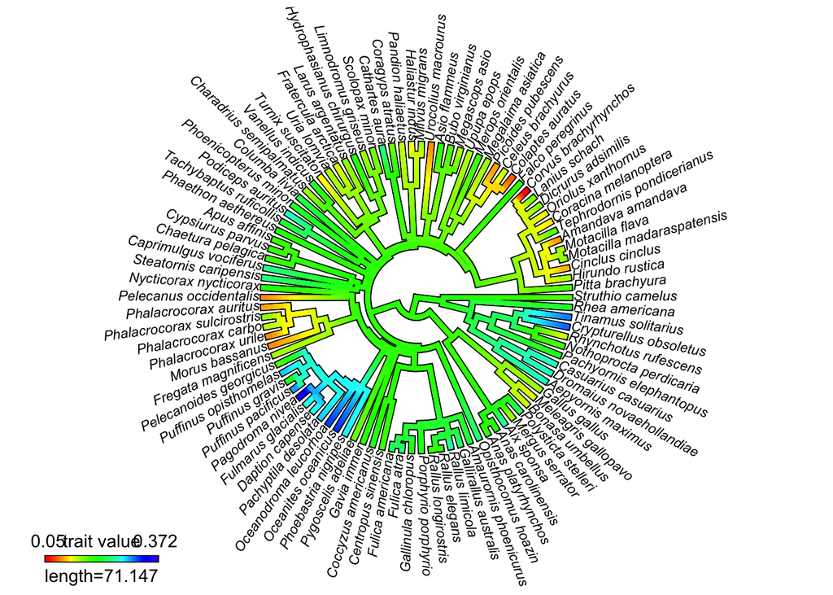

```r
# for a fan shape:
plot(obj, type = "fan", legend = 0.7 * max(nodeHeights(pruned)), fsize = c(0.7,
    0.9))
```

```r
# another ancestral state reconstruction
svl2 <- as.matrix(brain_meas)[, 8]
fit <- fastAnc(pruned, svl2, vars = TRUE, CI = TRUE)
fit
```

```
## Ancestral character estimates using fastAnc:
##       99      100      101      102      103      104      105      106
## 0.201424 0.195149 0.193734 0.192714 0.185546 0.180131 0.178760 0.157692
##      107      108      109      110      111      112      113      114
## 0.140687 0.132588 0.131986 0.129898 0.149175 0.138123 0.136727 0.136144
##      115      116      117      118      119      120      121      122
## 0.134666 0.129746 0.178558 0.176307 0.166658 0.160665 0.140150 0.116820
##      123      124      125      126      127      128      129      130
## 0.115548 0.162094 0.173665 0.171467 0.177992 0.150554 0.139372 0.202699
##      131      132      133      134      135      136      137      138
## 0.170077 0.166904 0.171979 0.164062 0.163627 0.153782 0.150566 0.181411
##      139      140      141      142      143      144      145      146
## 0.196354 0.197609 0.198343 0.206580 0.237897 0.201835 0.203966 0.189408
##      147      148      149      150      151      152      153      154
## 0.187822 0.194955 0.194633 0.193857 0.192809 0.185448 0.181202 0.149185
```

[output cut: 140 more lines]

Overall, our results are close to those of the original paper. Habitat scorings are needed to verify some of their ANOVA scores. Additional edits to the ancestral state reconstruction-tree figure were performed by the authors in photoshop, and that is not replicated here.

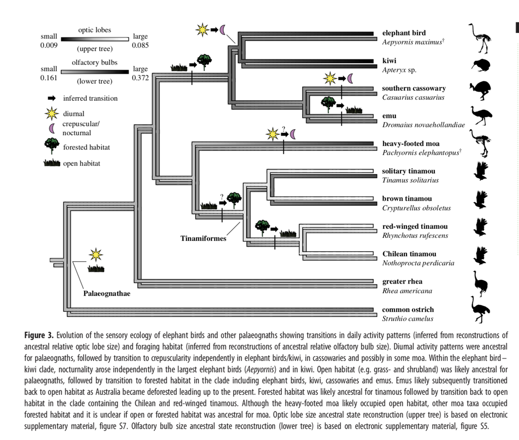

## References

Torres, Christopher R., and J. A. Clarke. Nocturnal giants: evolution of the sensory ecology in elephant birds and other palaeognaths inferred from digital brain reconstructions. Proc. Royal Society B 285: 20181540. http://dx.doi.org/10.1098/rspb.2018.1540.